# Bank Churn Prediction Neural Network

```python
# Installing tensor flow

!pip install tensorflow==2.2.0
```

```python
# Importing all standard libraries

import tensorflow as tf
import pandas as pd
import numpy as np
import seaborn as sns
import matplotlib.pyplot as plt
%matplotlib inline
import warnings
warnings.filterwarnings('ignore')

# Model preparation and metrics specific libraries

from sklearn.model_selection import train_test_split
from sklearn import preprocessing
from sklearn.preprocessing import MinMaxScaler, StandardScaler
from sklearn import metrics
from sklearn.metrics import accuracy_score, confusion_matrix, precision_score, recall_score, f1_score, precision_recall_curve, auc

# Model specific libraries

import tensorflow as tf
from tensorflow.keras.models import Sequential
from tensorflow.keras.layers import Dense
from tensorflow.keras import optimizers
```

```python
# Importing dataset

bank = pd.read_csv(r'c:\users\kokila.narayanan\Downloads\bank_churn.csv')
```

```python
bank.head()
```

|  | RowNumber | CustomerId | Surname | CreditScore | Geography | Gender | Age | Tenure | Balance | NumOfProducts | HasCrCard | IsActiveMember | EstimatedSalary | Exited |
| --- | --- | --- | --- | --- | --- | --- | --- | --- | --- | --- | --- | --- | --- | --- |
| 0 | 1 | 15634602 | Hargrave | 619 | France | Female | 42 | 2 | 0.00 | 1 | 1 | 1 | 101348.88 | 1 |
| 1 | 2 | 15647311 | Hill | 608 | Spain | Female | 41 | 1 | 83807.86 | 1 | 0 | 1 | 112542.58 | 0 |
| 2 | 3 | 15619304 | Onio | 502 | France | Female | 42 | 8 | 159660.80 | 3 | 1 | 0 | 113931.57 | 1 |
| 3 | 4 | 15701354 | Boni | 699 | France | Female | 39 | 1 | 0.00 | 2 | 0 | 0 | 93826.63 | 0 |
| 4 | 5 | 15737888 | Mitchell | 850 | Spain | Female | 43 | 2 | 125510.82 | 1 | 1 | 1 | 79084.10 | 0 |

```python
bank.shape
```

```
(10000, 14)
```

```python
bank.dtypes
```

```
RowNumber            int64
CustomerId           int64
Surname             object
CreditScore          int64
Geography           object
Gender              object
Age                  int64
Tenure               int64
Balance            float64
NumOfProducts        int64
HasCrCard            int64
IsActiveMember       int64
EstimatedSalary    float64
Exited               int64
dtype: object
```

```python
bank.info()
```

[output not shown]

```python
bank.isnull().sum()
```

[output not shown]

```python
bank[bank.duplicated()]
```

|  | RowNumber | CustomerId | Surname | CreditScore | Geography | Gender | Age | Tenure | Balance | NumOfProducts | HasCrCard | IsActiveMember | EstimatedSalary | Exited |
| --- | --- | --- | --- | --- | --- | --- | --- | --- | --- | --- | --- | --- | --- | --- |

```python
bank.drop(['RowNumber','CustomerId','Surname'],axis=1, inplace=True)
```

```python
bank.head()
```

|  | CreditScore | Geography | Gender | Age | Tenure | Balance | NumOfProducts | HasCrCard | IsActiveMember | EstimatedSalary | Exited |
| --- | --- | --- | --- | --- | --- | --- | --- | --- | --- | --- | --- |
| 0 | 619 | France | Female | 42 | 2 | 0.00 | 1 | 1 | 1 | 101348.88 | 1 |
| 1 | 608 | Spain | Female | 41 | 1 | 83807.86 | 1 | 0 | 1 | 112542.58 | 0 |
| 2 | 502 | France | Female | 42 | 8 | 159660.80 | 3 | 1 | 0 | 113931.57 | 1 |
| 3 | 699 | France | Female | 39 | 1 | 0.00 | 2 | 0 | 0 | 93826.63 | 0 |
| 4 | 850 | Spain | Female | 43 | 2 | 125510.82 | 1 | 1 | 1 | 79084.10 | 0 |

This leaves us with 2 Object/categorical columns : 'Geography' and 'Gender'. Before we start building model, we can do one-hot encoding of these two features.

```python
bank.describe()
```

|  | CreditScore | Age | Tenure | Balance | NumOfProducts | HasCrCard | IsActiveMember | EstimatedSalary | Exited |
| --- | --- | --- | --- | --- | --- | --- | --- | --- | --- |
| count | 10000.000000 | 10000.000000 | 10000.000000 | 10000.000000 | 10000.000000 | 10000.00000 | 10000.000000 | 10000.000000 | 10000.000000 |
| mean | 650.528800 | 38.921800 | 5.012800 | 76485.889288 | 1.530200 | 0.70550 | 0.515100 | 100090.239881 | 0.203700 |
| std | 96.653299 | 10.487806 | 2.892174 | 62397.405202 | 0.581654 | 0.45584 | 0.499797 | 57510.492818 | 0.402769 |
| min | 350.000000 | 18.000000 | 0.000000 | 0.000000 | 1.000000 | 0.00000 | 0.000000 | 11.580000 | 0.000000 |
| 25% | 584.000000 | 32.000000 | 3.000000 | 0.000000 | 1.000000 | 0.00000 | 0.000000 | 51002.110000 | 0.000000 |
| 50% | 652.000000 | 37.000000 | 5.000000 | 97198.540000 | 1.000000 | 1.00000 | 1.000000 | 100193.915000 | 0.000000 |
| 75% | 718.000000 | 44.000000 | 7.000000 | 127644.240000 | 2.000000 | 1.00000 | 1.000000 | 149388.247500 | 0.000000 |
| max | 850.000000 | 92.000000 | 10.000000 | 250898.090000 | 4.000000 | 1.00000 | 1.000000 | 199992.480000 | 1.000000 |

##### Insights:

1. Most of the mean and median are almost the same
2. There is a huge variance between mean and median of 'Balance'. Mean is on the left of median showing a left-skewed distribution due to potential outliers
3. Since balance may be an important feature that impacts the churn, we are not considering any outlier treatment for this classification neural network

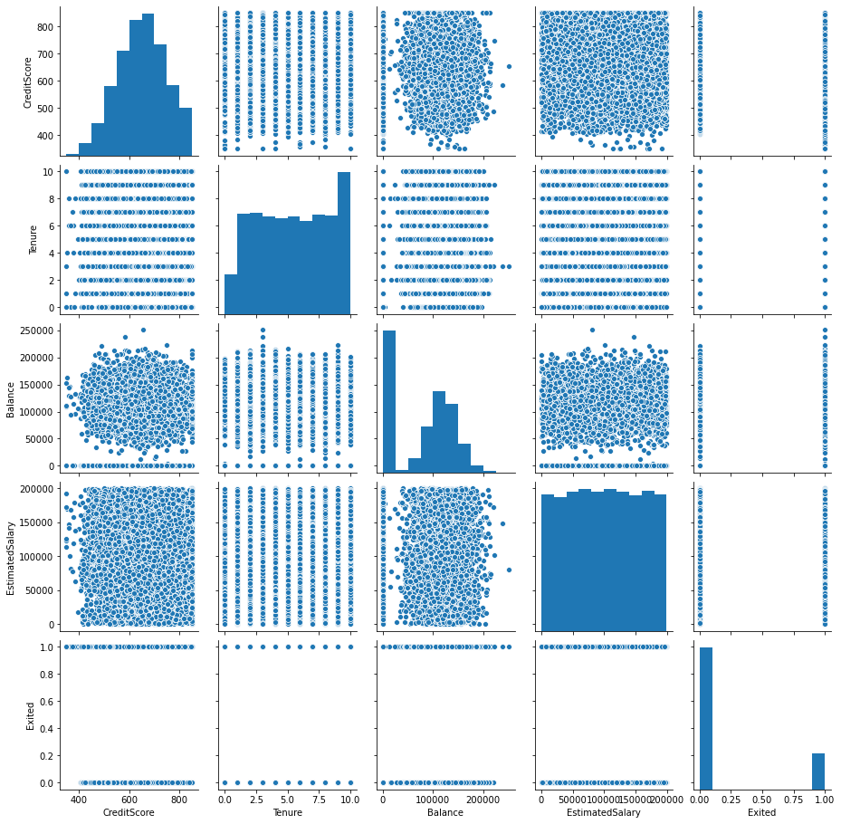

```python
# Pairplot between all numeric values

sns.pairplot(bank,vars=['CreditScore','Tenure','Balance','EstimatedSalary','Exited'])
```

##### Insights:

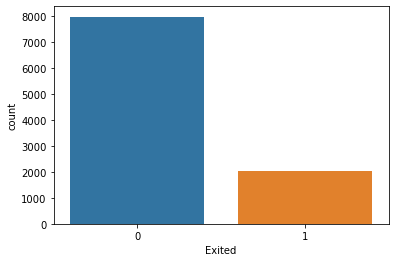

```python
# What is the split between Exited vs Not exited?

sns.countplot(bank['Exited'])
```

##### Dataset is very imbalanced. This would impact our metrics from the model.

```python
# Crosstab to find relation between categorical features and dependent variable

pd.crosstab(bank['Geography'],bank['Exited'])
```

| Exited Geography | 0 | 1 |
| --- | --- | --- |
| France | 4204 | 810 |
| Germany | 1695 | 814 |
| Spain | 2064 | 413 |

```python
pd.crosstab(bank['Gender'],bank['Exited'])
```

| Exited Gender | 0 | 1 |
| --- | --- | --- |
| Female | 3404 | 1139 |
| Male | 4559 | 898 |

```python
pd.crosstab(bank['HasCrCard'],bank['Exited'])
```

| Exited HasCrCard | 0 | 1 |
| --- | --- | --- |
| 0 | 2332 | 613 |
| 1 | 5631 | 1424 |

```python
pd.crosstab(bank['NumOfProducts'],bank['Exited'])
```

| Exited NumOfProducts | 0 | 1 |
| --- | --- | --- |
| 1 | 3675 | 1409 |
| 2 | 4242 | 348 |
| 3 | 46 | 220 |
| 4 | 0 | 60 |

```python
pd.crosstab(bank['IsActiveMember'],bank['Exited'])
```

| Exited IsActiveMember | 0 | 1 |
| --- | --- | --- |
| 0 | 3547 | 1302 |
| 1 | 4416 | 735 |

##### Insights:

1. Germany has the highest churn of people exiting
2. Female Customers exit more than males
3. As number of products increase, there is a relative shift in people exiting
4. Inactive members exit more than active members

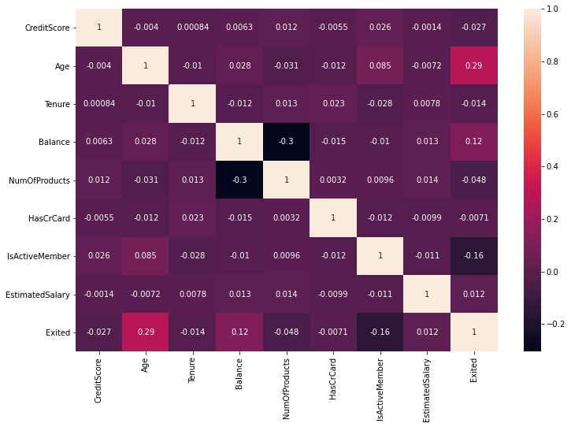

```python
# Heatmap

plt.figure(figsize=(12,8))
sns.heatmap(bank.corr(),annot=True)
plt.show()
```

From the heatmap, it can be observed that most of these features have negative to least correlation with each other.

```python
# Model preparation

# One-hot encoding for 'Geography' and 'Gender' columns

bankchurn = pd.get_dummies(bank,columns=['Geography','Gender'])
bankchurn.head()
```

|  | CreditScore | Age | Tenure | Balance | NumOfProducts | HasCrCard | IsActiveMember | EstimatedSalary | Exited | Geography_France | Geography_Germany | Geography_Spain | Gender_Female | Gender_Male |
| --- | --- | --- | --- | --- | --- | --- | --- | --- | --- | --- | --- | --- | --- | --- |
| 0 | 619 | 42 | 2 | 0.00 | 1 | 1 | 1 | 101348.88 | 1 | 1 | 0 | 0 | 1 | 0 |
| 1 | 608 | 41 | 1 | 83807.86 | 1 | 0 | 1 | 112542.58 | 0 | 0 | 0 | 1 | 1 | 0 |
| 2 | 502 | 42 | 8 | 159660.80 | 3 | 1 | 0 | 113931.57 | 1 | 1 | 0 | 0 | 1 | 0 |
| 3 | 699 | 39 | 1 | 0.00 | 2 | 0 | 0 | 93826.63 | 0 | 1 | 0 | 0 | 1 | 0 |
| 4 | 850 | 43 | 2 | 125510.82 | 1 | 1 | 1 | 79084.10 | 0 | 0 | 0 | 1 | 1 | 0 |

```python
# Splitting dataframe into X and y (Separating dependent variable into a dataframe)
X = bankchurn.copy()
X.drop('Exited',axis=1,inplace=True)
X.head()
```

|  | CreditScore | Age | Tenure | Balance | NumOfProducts | HasCrCard | IsActiveMember | EstimatedSalary | Geography_France | Geography_Germany | Geography_Spain | Gender_Female | Gender_Male |
| --- | --- | --- | --- | --- | --- | --- | --- | --- | --- | --- | --- | --- | --- |
| 0 | 619 | 42 | 2 | 0.00 | 1 | 1 | 1 | 101348.88 | 1 | 0 | 0 | 1 | 0 |
| 1 | 608 | 41 | 1 | 83807.86 | 1 | 0 | 1 | 112542.58 | 0 | 0 | 1 | 1 | 0 |
| 2 | 502 | 42 | 8 | 159660.80 | 3 | 1 | 0 | 113931.57 | 1 | 0 | 0 | 1 | 0 |
| 3 | 699 | 39 | 1 | 0.00 | 2 | 0 | 0 | 93826.63 | 1 | 0 | 0 | 1 | 0 |
| 4 | 850 | 43 | 2 | 125510.82 | 1 | 1 | 1 | 79084.10 | 0 | 0 | 1 | 1 | 0 |

```python
y = bankchurn['Exited']
y.head()
```

```
0    1
1    0
2    1
3    0
4    0
Name: Exited, dtype: int64
```

```python
# Splitting data in train and test sets
X_train,X_test,y_train,y_test = train_test_split(X,y,test_size=0.30,random_state=7)
```

```python
# Normalizing X train and test dataset

# Define Scaler
scaler = StandardScaler().fit(X_train)

# Scale the train set
X_train = scaler.transform(X_train)

# Scale the test set
X_test = scaler.transform(X_test)
```

#### Deep Neural Network

```python
# Initialize the model

model = Sequential()

# Add first hidden layer
model.add(Dense(64,activation='relu',kernel_initializer='normal'))

# Second hidden layer
# model.add(Dense(20,activation='relu',kernel_initializer='normal'))

# Output layer with one neuron
model.add(Dense(1,activation='sigmoid'))
```

```python
# Optimizer

optimizer = tf.keras.optimizers.Adam(0.0001)
# optimizer = tf.keras.optimizers.RMSprop(0.0001)

model.compile(loss='binary_crossentropy',optimizer=optimizer,metrics=['accuracy'])

epochs=50
```

```python
history = model.fit(X_train,y_train,batch_size=25,epochs=epochs,validation_split=0.2,verbose=False)

hist=pd.DataFrame(history.history)
hist['epoch'] = history.epoch
print(hist.info)
```

[output not shown]

[output cut: 42 more lines]

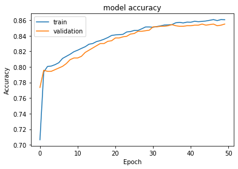

```python
# Plotting accuracy

plt.plot(hist['accuracy'])
plt.plot(hist['val_accuracy'])
plt.title('model accuracy')
plt.ylabel('Accuracy')
plt.xlabel('Epoch')
plt.legend(['train', 'validation'], loc='upper left')
plt.show()
```

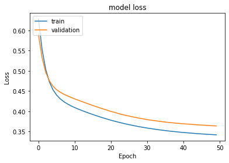

```python
# Plotting loss

plt.plot(hist['loss'])
plt.plot(hist['val_loss'])
plt.title('model loss')
plt.ylabel('Loss')
plt.xlabel('Epoch')
plt.legend(['train', 'validation'], loc='upper left')
plt.show()
```

##### Observations:

1. I tried the following manual hyperparameter tuning before landing in the current model above
2. Started with 1 layer. When i added a second layer, the model's performance in the training data went down so i left 1 layer only
3. I tried Adam and RMSprop optimizer
4. Learning rate tried for both Adam and RMSprop : 0.01,0.001,0.0001
5. Epochs values checked : 50,100,500

The best accuracy and loss results came with Adam(0.0001) and Epoch=50

```python
# Running against Test data

y_pred = model.predict(X_test)
```

```python
y_pred
```

```
array([[0.28658816],
       [0.14217353],
       [0.03093243],
       ...,
       [0.00542286],
       [0.02486557],
       [0.19152543]], dtype=float32)
```

```python
# Setting threshold of 0.5

y_pred = y_pred > 0.5
y_pred
```

```
array([[False],
       [False],
       [False],
       ...,
       [False],
       [False],
       [False]])
```

```python
# Getting accuracy and other metrics for the model

modelmetrics =metrics.classification_report(y_test,y_pred)
print(modelmetrics)
print('The accuracy score for the model is: ',accuracy_score(y_test,y_pred))
```

```
              precision    recall  f1-score   support

           0       0.87      0.97      0.92      2395
           1       0.77      0.43      0.55       605

    accuracy                           0.86      3000
   macro avg       0.82      0.70      0.73      3000
weighted avg       0.85      0.86      0.84      3000

The accuracy score for the model is:  0.859
```

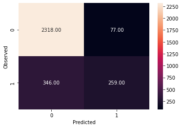

```python
# Confusion matrix

sns.heatmap(confusion_matrix(y_test,y_pred),annot=True,  fmt='.2f', xticklabels = [0,1] , yticklabels = [0,1])
plt.ylabel('Observed')
plt.xlabel('Predicted')
plt.show()
```

##### Closing Insights:

1. The model has an accuracy of 86% on the test data
2. Since the problem statement is focused on bank identifying churn or the customers who are likely to exit, it is important that we find the most number of true positives or minimize false negative and hence recall should be our primary focus.
3. But recall for the actual exited customers is low. This is because the dataset is very imbalanced.